# Decision Tree In-Class Exercise: Customer Churn Prediction

Ralchukwu Mogbogu

2025-11-05

# Introduction

Welcome to the Decision Tree in-class exercise! In this exercise, you will apply the concepts learned in today’s lecture to build and evaluate decision tree models for predicting customer churn.

**Scenario:** You are working as a data scientist for a telecommunications company. The company is experiencing customer churn (customers leaving the service) and wants to predict which customers are likely to churn so they can take proactive retention measures.

**Dataset:** `customer_churn_data.csv` contains information about 300 customers with the following variables: - `CustomerID`: Unique identifier - `Age`: Customer age - `TenureMonths`: How long the customer has been with the company - `MonthlyCharges`: Monthly subscription fee - `TotalCharges`: Total amount charged to the customer - `ContractType`: Type of contract (Month-to-Month, One Year, Two Year) - `InternetService`: Type of internet service (DSL, Fiber Optic, No) - `TechSupport`: Whether customer has tech support (Yes/No) - `OnlineSecurity`: Whether customer has online security (Yes/No) - `NumSupportCalls`: Number of support calls made - `Churn`: Target variable - Did the customer churn? (Yes/No)

**Time:** 40 minutes

# Section 1: Data Preparation and Exploration (8 minutes)

## 1.1 Load Required Libraries

Load the necessary libraries for this exercise.

```r
# Load required libraries
# YOUR CODE HERE
library(readxl)
library(caret)
library(dplyr)

library(rpart)
library(rpart.plot)
library(Metrics)
```

## 1.2 Load and Explore the Data

Load the dataset and examine its structure.

```r
# Load the customer churn dataset
# YOUR CODE HERE
df <- read_excel("customer_churn_data.xlsx")
head(df)
```

```
## # A tibble: 6 × 11
##   CustomerID   Age TenureMonths MonthlyCharges TotalCharges ContractType
##   <chr>      <dbl>        <dbl>          <dbl>        <dbl> <chr>
## 1 CUST0001      19           34           56.4        1798. Month-to-Month
## 2 CUST0002      24           41           46.3        1825. Month-to-Month
## 3 CUST0003      66           17          114.         2006. Month-to-Month
## 4 CUST0004      62           12           67.1         886. Month-to-Month
## 5 CUST0005      64           58           84.6        4846. Month-to-Month
## 6 CUST0006      65            5           68.3         334. Two Year
## # ℹ 5 more variables: InternetService <chr>, TechSupport <chr>,
## #   OnlineSecurity <chr>, NumSupportCalls <dbl>, Churn <chr>
```

```r
# Display the first few rows
# YOUR CODE HERE
head(df, 10)
```

```
## # A tibble: 10 × 11
##    CustomerID   Age TenureMonths MonthlyCharges TotalCharges ContractType
##    <chr>      <dbl>        <dbl>          <dbl>        <dbl> <chr>
##  1 CUST0001      19           34           56.4        1798. Month-to-Month
##  2 CUST0002      24           41           46.3        1825. Month-to-Month
##  3 CUST0003      66           17          114.         2006. Month-to-Month
##  4 CUST0004      62           12           67.1         886. Month-to-Month
##  5 CUST0005      64           58           84.6        4846. Month-to-Month
##  6 CUST0006      65            5           68.3         334. Two Year
##  7 CUST0007      29           22           48.3        1142. Month-to-Month
##  8 CUST0008      49           30           95.9        3086. One Year
##  9 CUST0009      58           46           98.9        4606. One Year
## 10 CUST0010      41           47           93.5        4342. Month-to-Month
## # ℹ 5 more variables: InternetService <chr>, TechSupport <chr>,
## #   OnlineSecurity <chr>, NumSupportCalls <dbl>, Churn <chr>
```

```r
# Check the structure of the data
# YOUR CODE HERE
str(df)
```

```
## tibble [300 × 11] (S3: tbl_df/tbl/data.frame)
##  $ CustomerID     : chr [1:300] "CUST0001" "CUST0002" "CUST0003" "CUST0004" ...
##  $ Age            : num [1:300] 19 24 66 62 64 65 29 49 58 41 ...
##  $ TenureMonths   : num [1:300] 34 41 17 12 58 5 22 30 46 47 ...
##  $ MonthlyCharges : num [1:300] 56.4 46.3 113.5 67.1 84.6 ...
##  $ TotalCharges   : num [1:300] 1798 1825 2006 886 4846 ...
##  $ ContractType   : chr [1:300] "Month-to-Month" "Month-to-Month" "Month-to-Month" "Month-to-Month" ...
##  $ InternetService: chr [1:300] "Fiber Optic" "DSL" "DSL" "No" ...
##  $ TechSupport    : chr [1:300] "No" "Yes" "Yes" "Yes" ...
##  $ OnlineSecurity : chr [1:300] "No" "No" "No" "Yes" ...
##  $ NumSupportCalls: num [1:300] 0 2 2 2 1 5 2 1 3 1 ...
##  $ Churn          : chr [1:300] "No" "No" "No" "No" ...
```

```r
# Get summary statistics
# YOUR CODE HERE
summary(df)
```

```
##   CustomerID             Age         TenureMonths   MonthlyCharges
##  Length:300         Min.   :18.00   Min.   : 1.00   Min.   : 20.11
##  Class :character   1st Qu.:30.75   1st Qu.:19.00   1st Qu.: 44.31
##  Mode  :character   Median :43.00   Median :37.00   Median : 67.70
##                     Mean   :43.04   Mean   :36.57   Mean   : 68.15
##                     3rd Qu.:56.00   3rd Qu.:54.00   3rd Qu.: 91.64
##                     Max.   :69.00   Max.   :71.00   Max.   :119.95
##   TotalCharges    ContractType       InternetService    TechSupport
##  Min.   :-128.4   Length:300         Length:300         Length:300
##  1st Qu.: 947.7   Class :character   Class :character   Class :character
##  Median :2170.3   Mode  :character   Mode  :character   Mode  :character
##  Mean   :2480.6
##  3rd Qu.:3508.6
##  Max.   :7818.3
##  OnlineSecurity     NumSupportCalls    Churn
##  Length:300         Min.   :0.00    Length:300
##  Class :character   1st Qu.:1.00    Class :character
##  Mode  :character   Median :2.00    Mode  :character
##                     Mean   :2.02
##                     3rd Qu.:3.00
##                     Max.   :7.00
```

**Question 1.1:** How many customers are in the dataset? How many features (excluding CustomerID and Churn)?

**Your Answer:** Since the Tibble shows “300 x 11,” the number of customers will be 300, as in 300 rows of customers in the data. The features are 11 (variables) in total, so if we exclude CustomerID and Churn, we are left with 9. Therefore, there are 300 customers and 9 features

**Question 1.2:** What is the distribution of the target variable `Churn`? What percentage of customers churned?

**Your Answer:**

```r
# distribution

distr <- table(df$Churn)
print ("distribution of the target variable `Churn`:")
```

```
## [1] "distribution of the target variable `Churn`:"
```

```r
print(distr)
```

```
##
##  No Yes
## 183 117
```

```r
# percentage customers churned
print("percentage of customers churned:")
```

```
## [1] "percentage of customers churned:"
```

```r
print((distr/300) * 100)
```

```
##
##  No Yes
##  61  39
```

**Your Answer:** Among 300 customers, the distrubition of the target variable “Churn” is 117 Yes and 183 No. By that reseoning to find of the percentage of customers churned, the Yes frequency is divided by the total 300 and multiplied by 100; i.e, (117/300)*100, which will give a value of 39. Therefore, the percentage of customers churned is 39%

## 1.3 Data Preprocessing

Convert categorical variables to factors and split the data into training (70%) and testing (30%) sets.

```r
sum(is.na(df)) # no missing values
```

```
## [1] 0
```

```r
# Remove CustomerID as it's not useful for prediction
# YOUR CODE HERE


df_new <- df[, !names(df) %in% "CustomerID"]


# Convert categorical variables to factors
# YOUR CODE HERE
catVariables <- names(df_new)[sapply(df_new, is.character)]
str(catVariables)
```

```
##  chr [1:5] "ContractType" "InternetService" "TechSupport" "OnlineSecurity" ...
```

```r
df_new[catVariables] <- lapply(df_new[catVariables], as.factor)
str(df_new)
```

```
## tibble [300 × 10] (S3: tbl_df/tbl/data.frame)
##  $ Age            : num [1:300] 19 24 66 62 64 65 29 49 58 41 ...
##  $ TenureMonths   : num [1:300] 34 41 17 12 58 5 22 30 46 47 ...
##  $ MonthlyCharges : num [1:300] 56.4 46.3 113.5 67.1 84.6 ...
##  $ TotalCharges   : num [1:300] 1798 1825 2006 886 4846 ...
##  $ ContractType   : Factor w/ 3 levels "Month-to-Month",..: 1 1 1 1 1 3 1 2 2 1 ...
##  $ InternetService: Factor w/ 3 levels "DSL","Fiber Optic",..: 2 1 1 3 3 2 3 2 1 2 ...
##  $ TechSupport    : Factor w/ 2 levels "No","Yes": 1 2 2 2 1 2 2 1 1 2 ...
##  $ OnlineSecurity : Factor w/ 2 levels "No","Yes": 1 1 1 2 1 1 2 1 2 1 ...
##  $ NumSupportCalls: num [1:300] 0 2 2 2 1 5 2 1 3 1 ...
##  $ Churn          : Factor w/ 2 levels "No","Yes": 1 1 1 1 2 2 1 2 2 1 ...
```

```r
# Set seed for reproducibility
set.seed(530)

# Create training and testing sets (70/30 split)
# YOUR CODE HERE

X <- df_new[, -ncol(df_new)]
Y <- df_new$Churn

train_index <- createDataPartition(Y, p = 0.7, list = FALSE)

X_train <- X[train_index, ]
X_test  <- X[-train_index, ]
y_train <- Y[train_index]
y_test  <- Y[-train_index]

# Verify the split
# YOUR CODE HERE

# check the size for both training and testing
cat("Training:", nrow(X_train), "\n")
```

```
## Training: 211
```

```r
cat("Testing:", nrow(X_test), "\n\n")
```

```
## Testing: 89
```

```r
cat("\nTraining Class:\n")
```

```
##
## Training Class:
```

```r
print(prop.table(table(y_train)) * 100)
```

```
## y_train
##       No      Yes
## 61.13744 38.86256
```

```r
cat("Testing Class:\n")
```

```
## Testing Class:
```

```r
print(prop.table(table(y_test)) * 100)
```

```
## y_test
##       No      Yes
## 60.67416 39.32584
```

**Question 1.3:** How many observations are in your training set and testing set?

**Your Answer:** Using the stratified sampling method, we obtained 211 training and 89 testing observations. This approach is necessary to maintain class balance in the churn and prevents bias caused by class imbalance.

# Section 2: Building Your First Decision Tree (10 minutes)

## 2.1 Build a Basic Decision Tree

Build a decision tree using the `rpart` package with default settings.

```r
# Build a decision tree with default parameters
# YOUR CODE HERE
trainData <- cbind(X_train, Churn=y_train)
testData <- cbind(X_test,  Churn = y_test)

treemodel <- rpart(Churn ~ ., data = trainData, method = "class")

# Print the tree summary
# YOUR CODE HERE

print(treemodel)
```

```
## n= 211
##
## node), split, n, loss, yval, (yprob)
##       * denotes terminal node
##
##   1) root 211 82 No (0.61137441 0.38862559)
##     2) TenureMonths>=6.5 194 66 No (0.65979381 0.34020619)
##       4) NumSupportCalls< 3.5 172 50 No (0.70930233 0.29069767)
##         8) TechSupport=Yes 82 13 No (0.84146341 0.15853659) *
##         9) TechSupport=No 90 37 No (0.58888889 0.41111111)
##          18) TotalCharges>=4319.955 17  2 No (0.88235294 0.11764706) *
##          19) TotalCharges< 4319.955 73 35 No (0.52054795 0.47945205)
##            38) ContractType=One Year,Two Year 35 13 No (0.62857143 0.37142857)
##              76) TotalCharges< 2759.395 26  7 No (0.73076923 0.26923077) *
##              77) TotalCharges>=2759.395 9  3 Yes (0.33333333 0.66666667) *
##            39) ContractType=Month-to-Month 38 16 Yes (0.42105263 0.57894737)
##              78) Age>=47 15  5 No (0.66666667 0.33333333) *
##              79) Age< 47 23  6 Yes (0.26086957 0.73913043)
##               158) Age< 25 8  3 No (0.62500000 0.37500000) *
##               159) Age>=25 15  1 Yes (0.06666667 0.93333333) *
##       5) NumSupportCalls>=3.5 22  6 Yes (0.27272727 0.72727273) *
##     3) TenureMonths< 6.5 17  1 Yes (0.05882353 0.94117647) *
```

```r
summary(treemodel)
```

```
## Call:
## rpart(formula = Churn ~ ., data = trainData, method = "class")
##   n= 211
##
##           CP nsplit rel error    xerror       xstd
## 1 0.18292683      0 1.0000000 1.0000000 0.08634689
## 2 0.12195122      1 0.8170732 0.9268293 0.08503909
## 3 0.02439024      2 0.6951220 0.8902439 0.08426474
## 4 0.01000000      8 0.5000000 0.8414634 0.08310241
##
## Variable importance
##    TotalCharges    TenureMonths NumSupportCalls             Age     TechSupport
##              28              25              16              11              10
##  MonthlyCharges    ContractType  OnlineSecurity InternetService
##               6               3               1               1
##
## Node number 1: 211 observations,    complexity param=0.1829268
##   predicted class=No   expected loss=0.3886256  P(node) =1
##     class counts:   129    82
##    probabilities: 0.611 0.389
##   left son=2 (194 obs) right son=3 (17 obs)
##   Primary splits:
##       TenureMonths    < 6.5      to the right, improve=11.290270, (0 missing)
##       NumSupportCalls < 3.5      to the left,  improve= 9.377722, (0 missing)
##       TechSupport     splits as  RL,           improve= 8.101737, (0 missing)
##       TotalCharges    < 420.915  to the right, improve= 6.342646, (0 missing)
##       ContractType    splits as  RLL,          improve= 4.808337, (0 missing)
##   Surrogate splits:
##       TotalCharges < 417.045  to the right, agree=0.976, adj=0.706, (0 split)
##
## Node number 2: 194 observations,    complexity param=0.1219512
##   predicted class=No   expected loss=0.3402062  P(node) =0.9194313
##     class counts:   128    66
##    probabilities: 0.660 0.340
##   left son=4 (172 obs) right son=5 (22 obs)
##   Primary splits:
##       NumSupportCalls < 3.5      to the left,  improve=7.435278, (0 missing)
##       TechSupport     splits as  RL,           improve=6.259397, (0 missing)
##       ContractType    splits as  RLL,          improve=3.848311, (0 missing)
##       MonthlyCharges  < 110.785  to the right, improve=2.536901, (0 missing)
```

[output cut: 129 more lines]

```
##   Surrogate splits:
##       TotalCharges    < 1308.2   to the left,  agree=0.783, adj=0.375, (0 split)
##       NumSupportCalls < 2.5      to the right, agree=0.783, adj=0.375, (0 split)
##       TenureMonths    < 15.5     to the left,  agree=0.739, adj=0.250, (0 split)
##       MonthlyCharges  < 32.74    to the left,  agree=0.739, adj=0.250, (0 split)
##
## Node number 158: 8 observations
##   predicted class=No   expected loss=0.375  P(node) =0.03791469
##     class counts:     5     3
##    probabilities: 0.625 0.375
##
## Node number 159: 15 observations
##   predicted class=Yes  expected loss=0.06666667  P(node) =0.07109005
##     class counts:     1    14
##    probabilities: 0.067 0.933
```

**Question 2.1:** What is the root node split? Which variable was chosen first and why do you think this variable was selected?

**Your Answer:** The root node split will be the fist split in the decision tree which is Node 1. The variable chosen first is TenureMonths du3e to its <6.5 split

## 2.2 Visualize the Decision Tree

Create a visualization of your decision tree.

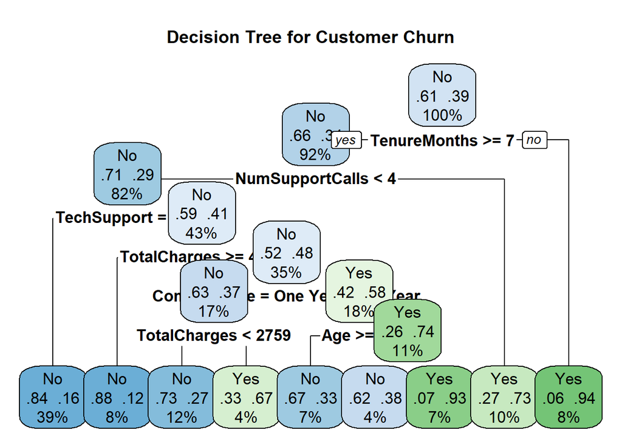

```r
# Visualize the tree using rpart.plot
# YOUR CODE HERE


rpart.plot(
  x = treemodel,                 # the decision tree object
  type = 2,                      # structure/label layout
  extra = +104,                # automatically choose info shown at nodes
  under = FALSE,                 # show text inside boxes, not underneath
  fallen.leaves = TRUE,          # align leaves at the bottom neatly
  digits = 2,                    # round numeric labels to 2 digits
  varlen = 0,                    # show full variable names
  faclen = 0,                    # show full factor level names
  roundint = TRUE,               # round splits if all values are integers
  cex = 0.9,                    # auto text size
  tweak = 1.2,                   # slightly enlarge text (like zoom)
  box.palette = "auto",          # auto-select color palette (like filled=True)
  shadow.col = 0,                # no box shadow (0 = off)
  main = "Decision Tree for Customer Churn"
)
```

**Question 2.2:** How many leaf nodes does your tree have? What is the maximum depth of the tree?

## 2.3 Variable Importance

Examine which variables are most important for the decision tree.

```r
# Display variable importance
# YOUR CODE HERE

df_varImportance <- data.frame(importance = treemodel$variable.importance)
df_varImportance
```

```
##                 importance
## TotalCharges    15.9110618
## TenureMonths    14.2093649
## NumSupportCalls  9.1224425
## Age              6.4223177
## TechSupport      5.4744060
## MonthlyCharges   3.4605014
## ContractType     1.5691832
## OnlineSecurity   0.7792404
## InternetService  0.3138366
```

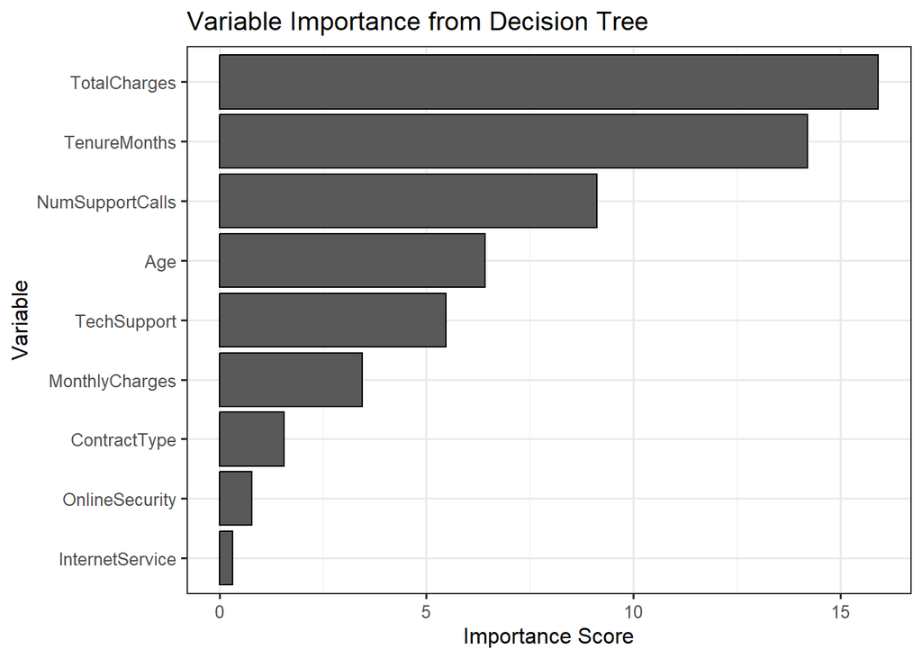

```r
# Create a variable importance plot
# YOUR CODE HERE

df2 <- df_varImportance %>%
  tibble::rownames_to_column(var = "variable") %>%
  arrange(importance) %>%
  mutate(variable = forcats::fct_inorder(variable))

# variable importance plot

ggplot(df2) +
  geom_col(aes(x = variable, y = importance),
           col='black', show.legend = F) +
  coord_flip() +
  labs(
    title = "Variable Importance from Decision Tree",
    x = "Variable",
    y = "Importance Score"
  ) + scale_fill_grey() +
  theme_bw(base_size = 12)
```

**Question 2.3:** List the top 3 most important variables according to your model. Do these make business sense for predicting churn?

**Your Answer:** These are the top 3 most importance variables based on our tree model.

- TotalCharges
- TenureMonths
- NumSupportCalls

# Section 3: Model Evaluation (8 minutes)

## 3.1 Make Predictions

Use your model to make predictions on the test set.

```r
# Make predictions on test set (class labels)
# YOUR CODE HERE

actual = y_test
predicted = predict(treemodel, newdata = X_test, type = "class")

compare_df = data.frame(
    Actual_Values = actual,
    Predicted_Values = predicted
)
compare_df
```

```
##    Actual_Values Predicted_Values
## 1             No               No
## 2             No               No
## 3            Yes               No
## 4             No               No
## 5             No              Yes
## 6            Yes               No
## 7            Yes               No
## 8            Yes               No
## 9            Yes              Yes
## 10            No               No
## 11            No              Yes
## 12            No               No
## 13           Yes               No
## 14           Yes              Yes
```

[output cut: 75 more lines]

```r
# Make predictions with probabilities
# YOUR CODE HERE

prob_predictions <- predict(treemodel, newdata = X_test, type = "prob")
head(prob_predictions, 10)
```

```
##            No       Yes
## 1  0.62500000 0.3750000
## 2  0.84146341 0.1585366
## 3  0.88235294 0.1176471
## 4  0.84146341 0.1585366
## 5  0.27272727 0.7272727
## 6  0.88235294 0.1176471
## 7  0.66666667 0.3333333
## 8  0.84146341 0.1585366
## 9  0.05882353 0.9411765
## 10 0.84146341 0.1585366
```

## 3.2 Create Confusion Matrix

Generate a confusion matrix to evaluate model performance.

```r
# Create confusion matrix
# YOUR CODE HERE

conf_matrix <- confusionMatrix(predicted, actual)
print(conf_matrix)
```

```
## Confusion Matrix and Statistics
##
##           Reference
## Prediction No Yes
##        No  35  21
##        Yes 19  14
##
##                Accuracy : 0.5506
##                  95% CI : (0.4414, 0.6562)
##     No Information Rate : 0.6067
##     P-Value [Acc > NIR] : 0.8831
##
##                   Kappa : 0.0486
##
##  Mcnemar's Test P-Value : 0.8744
##
##             Sensitivity : 0.6481
##             Specificity : 0.4000
##          Pos Pred Value : 0.6250
##          Neg Pred Value : 0.4242
##              Prevalence : 0.6067
##          Detection Rate : 0.3933
##    Detection Prevalence : 0.6292
##       Balanced Accuracy : 0.5241
##
##        'Positive' Class : No
##
```

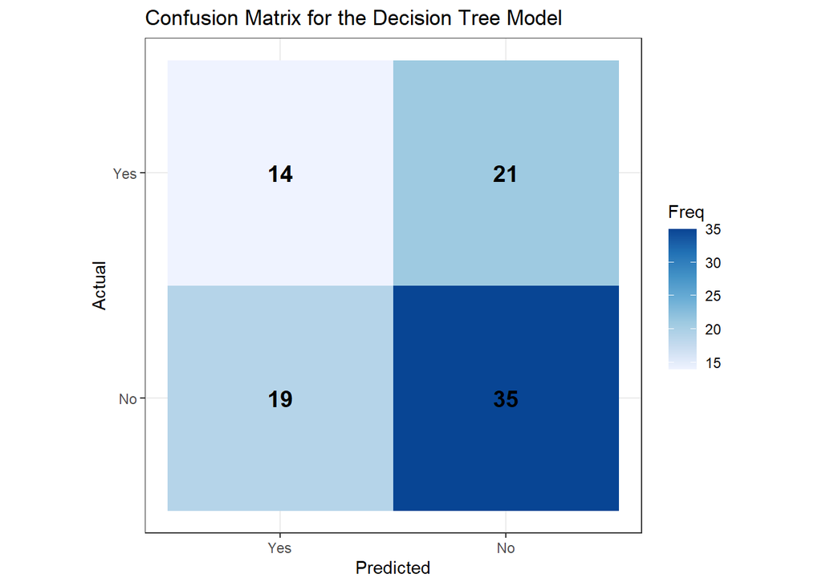

```r
# Display the confusion matrix
# YOUR CODE HERE

# converting new confusion matrix to data frame
conf_matrix_df <- as.data.frame(conf_matrix$table)
colnames(conf_matrix_df) <- c("Predicted", "Actual", "Freq")

# Reorder the factor levels so that "Yes" comes before "No"
conf_matrix_df$Predicted <- factor(conf_matrix_df$Predicted, levels = c("Yes", "No"))
conf_matrix_df$Actual <- factor(conf_matrix_df$Actual, levels = c("No","Yes"))

# confusion matrix using ggplot2
ggplot2::ggplot(conf_matrix_df, aes(x = Predicted, y = Actual, fill = Freq)) +
  geom_tile() +
  scale_fill_distiller(palette = "Blues", direction = 1) +
  geom_text(aes(label = Freq), color = "black", size = 5, fontface="bold") +
  theme(
    axis.text.x = element_text(size = 14),
    axis.title.x = element_text(size = 14),
    axis.text.y = element_text(size = 14),
    axis.title.y = element_text(size = 14)
    ) + theme_bw() + coord_equal() +
  labs(
    title = "Confusion Matrix for the Decision Tree Model",
    x = "Predicted",
    y = "Actual"
  )
```

**Question 3.1:** Fill in the values from your confusion matrix:

- True Positives (TP): 14
- False Positives (FP): 19
- True Negatives (TN): 35
- False Negatives (FN): 21

## 3.3 Calculate Performance Metrics

Calculate accuracy, precision, recall, and F1-score.

```r
# Calculate metrics from confusion matrix
# YOUR CODE HERE
# Ensure both actual and predicted are factors with same level order

compare_df_metrics <- compare_df

compare_df_metrics$Predicted_Values <- ifelse(compare_df_metrics$Predicted_Values == "Yes", 1, 0)
compare_df_metrics$Actual_Values    <- ifelse(compare_df_metrics$Actual_Values == "Yes", 1, 0)


recall_val = recall(compare_df_metrics$Actual_Values, compare_df_metrics$Predicted_Values)
precision_val = precision(compare_df_metrics$Actual_Values, compare_df_metrics$Predicted_Values)
f1_score = f1(compare_df_metrics$Actual_Values, compare_df_metrics$Predicted_Values)
acc_val = accuracy(compare_df_metrics$Actual_Values, compare_df_metrics$Predicted_Values)

# Print all metrics
# YOUR CODE HERE

cat("Recall:", recall_val, "\n")
```

```
## Recall: 0.4
```

```r
cat("Precision:", precision_val, "\n")
```

```
## Precision: 0.4242424
```

```r
cat("F1-score:", f1_score, "\n")
```

```
## F1-score: 1
```

```r
cat("Accuracy:", acc_val, "\n")
```

```
## Accuracy: 0.5505618
```

**Question 3.2:** What is the accuracy of your model? What does this tell you about the model’s performance?

**Your Answer:**

The model currently has an accuracy of 55.05%. This figure does not provide strong evidence of predictive performance, as it appears to predict churn status for over half of the customers in the test set. Although it is slightly above the fifty percent mark, it cannot be considered a reliable model for predicting churn status within the system. It fails to adequately capture the relationships between the independent variables and the dependent variables. This summarizes the current situation.

**Question 3.3:** Which is higher - precision or recall? What does this imply about your model’s behavior (does it make more false positive or false negative errors)?

**Your Answer:**

The model achieved a higher precision than recall, currently 0.42 and 0.4, respectively, indicating that the model was slightly better at minimizing false positives, predicting 42% of the cases identified as churn. However, it struggles with true positives, as it misses about 60% of actual churn cases, with a recall of only 40%. This discrepancy between precision and recall highlights an imbalance in the model’s performance, making it less effective at distinguishing between churn and non-churn customers.

# Section 4: Controlling Tree Complexity (10 minutes)

## 4.1 Build Trees with Different Complexity Parameters

Build three decision trees with different `cp` (complexity parameter) values to see how it affects the tree.

```r
# Tree with low cp (more complex tree)
# YOUR CODE HERE
# Source - https://stackoverflow.com/questions/37721047/selecting-cp-value-for-decision-tree-pruning-using-rpart
# Posted by Alan Chalk
# Retrieved 2025-11-05, License - CC BY-SA 3.0

printcp(treemodel)
```

```
##
## Classification tree:
## rpart(formula = Churn ~ ., data = trainData, method = "class")
##
## Variables actually used in tree construction:
## [1] Age             ContractType    NumSupportCalls TechSupport
## [5] TenureMonths    TotalCharges
##
## Root node error: 82/211 = 0.38863
##
## n= 211
##
##        CP nsplit rel error  xerror     xstd
## 1 0.18293      0   1.00000 1.00000 0.086347
## 2 0.12195      1   0.81707 0.92683 0.085039
## 3 0.02439      2   0.69512 0.89024 0.084265
## 4 0.01000      8   0.50000 0.84146 0.083102
```

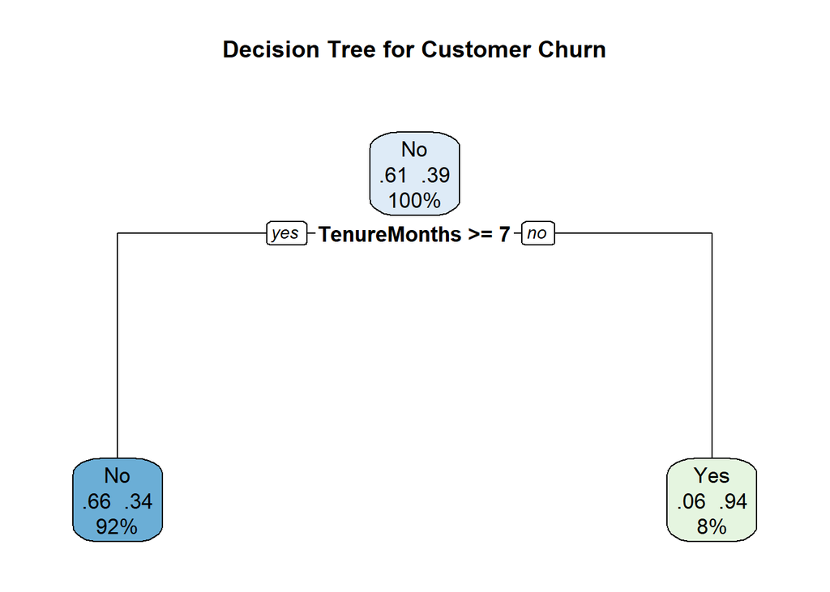

```r
treemodel1 <- rpart(Churn ~ ., data = trainData, method = "class", control = rpart.control(cp = 0.18))

# Tree with moderate cp
# YOUR CODE HERE

treemodel2 <- rpart(Churn ~ ., data = trainData, method = "class", control = rpart.control(cp = 0.12))


# Tree with high cp (simpler tree)
# YOUR CODE HERE

treemodel3 <- rpart(Churn ~ ., data = trainData, method = "class", control = rpart.control(cp = 0.02))


# Visualize all three trees
# YOUR CODE HERE


rpart.plot(
  x = treemodel1,                 # the decision tree object
  type = 2,                      # structure/label layout
  extra = +104,                # automatically choose info shown at nodes
  under = FALSE,                 # show text inside boxes, not underneath
  fallen.leaves = TRUE,          # align leaves at the bottom neatly
  digits = 2,                    # round numeric labels to 2 digits
  varlen = 0,                    # show full variable names
  faclen = 0,                    # show full factor level names
  roundint = TRUE,               # round splits if all values are integers
  cex = 0.9,                    # auto text size
  tweak = 1.2,                   # slightly enlarge text (like zoom)
  box.palette = "auto",          # auto-select color palette (like filled=True)
  shadow.col = 0,                # no box shadow (0 = off)
  main = "Decision Tree for Customer Churn"
)
```

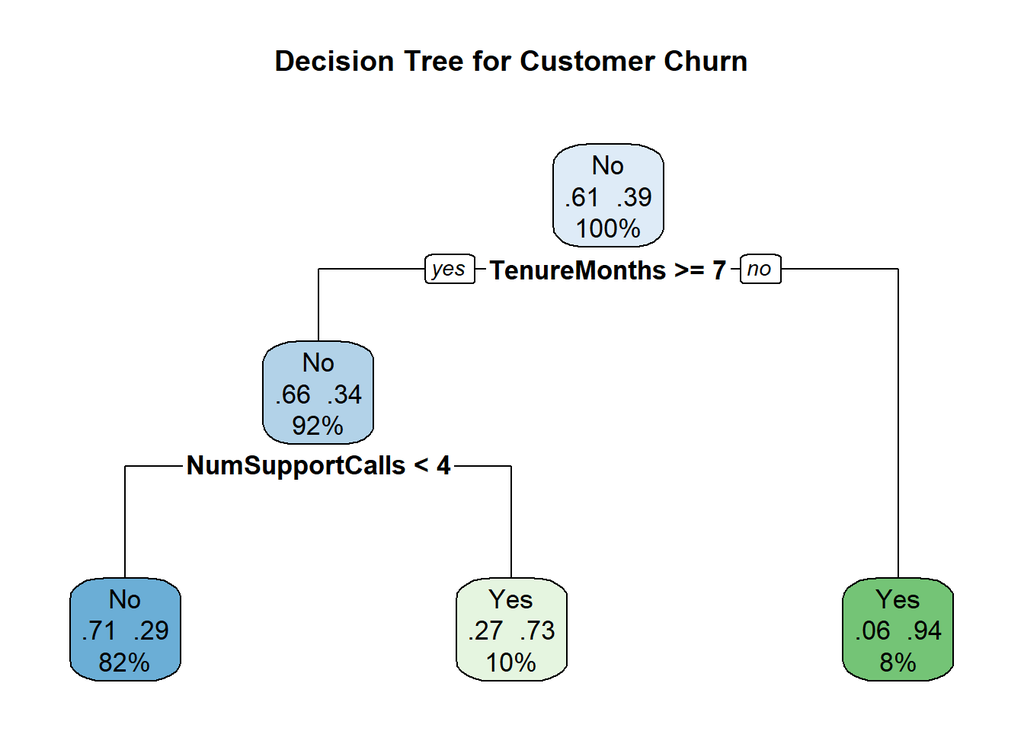

```r
rpart.plot(
  x = treemodel2,                 # the decision tree object
  type = 2,                      # structure/label layout
  extra = +104,                # automatically choose info shown at nodes
  under = FALSE,                 # show text inside boxes, not underneath
  fallen.leaves = TRUE,          # align leaves at the bottom neatly
  digits = 2,                    # round numeric labels to 2 digits
  varlen = 0,                    # show full variable names
  faclen = 0,                    # show full factor level names
  roundint = TRUE,               # round splits if all values are integers
  cex = 0.9,                    # auto text size
  tweak = 1.2,                   # slightly enlarge text (like zoom)
  box.palette = "auto",          # auto-select color palette (like filled=True)
  shadow.col = 0,                # no box shadow (0 = off)
  main = "Decision Tree for Customer Churn"
)
```

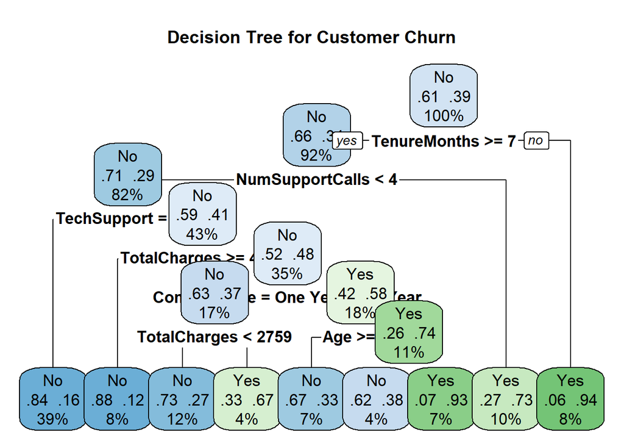

```r
rpart.plot(
  x = treemodel3,                 # the decision tree object
  type = 2,                      # structure/label layout
  extra = +104,                # automatically choose info shown at nodes
  under = FALSE,                 # show text inside boxes, not underneath
  fallen.leaves = TRUE,          # align leaves at the bottom neatly
  digits = 2,                    # round numeric labels to 2 digits
  varlen = 0,                    # show full variable names
  faclen = 0,                    # show full factor level names
  roundint = TRUE,               # round splits if all values are integers
  cex = 0.9,                    # auto text size
  tweak = 1.2,                   # slightly enlarge text (like zoom)
  box.palette = "auto",          # auto-select color palette (like filled=True)
  shadow.col = 0,                # no box shadow (0 = off)
  main = "Decision Tree for Customer Churn"
)
```

**Question 4.1:** How does changing the `cp` parameter affect the tree structure? Which tree is most complex and which is simplest?

```r
summary(treemodel)
```

```
## Call:
## rpart(formula = Churn ~ ., data = trainData, method = "class")
##   n= 211
##
##           CP nsplit rel error    xerror       xstd
## 1 0.18292683      0 1.0000000 1.0000000 0.08634689
## 2 0.12195122      1 0.8170732 0.9268293 0.08503909
## 3 0.02439024      2 0.6951220 0.8902439 0.08426474
## 4 0.01000000      8 0.5000000 0.8414634 0.08310241
##
## Variable importance
##    TotalCharges    TenureMonths NumSupportCalls             Age     TechSupport
##              28              25              16              11              10
##  MonthlyCharges    ContractType  OnlineSecurity InternetService
##               6               3               1               1
##
## Node number 1: 211 observations,    complexity param=0.1829268
##   predicted class=No   expected loss=0.3886256  P(node) =1
##     class counts:   129    82
##    probabilities: 0.611 0.389
##   left son=2 (194 obs) right son=3 (17 obs)
##   Primary splits:
##       TenureMonths    < 6.5      to the right, improve=11.290270, (0 missing)
##       NumSupportCalls < 3.5      to the left,  improve= 9.377722, (0 missing)
##       TechSupport     splits as  RL,           improve= 8.101737, (0 missing)
##       TotalCharges    < 420.915  to the right, improve= 6.342646, (0 missing)
##       ContractType    splits as  RLL,          improve= 4.808337, (0 missing)
##   Surrogate splits:
##       TotalCharges < 417.045  to the right, agree=0.976, adj=0.706, (0 split)
##
## Node number 2: 194 observations,    complexity param=0.1219512
##   predicted class=No   expected loss=0.3402062  P(node) =0.9194313
##     class counts:   128    66
##    probabilities: 0.660 0.340
##   left son=4 (172 obs) right son=5 (22 obs)
##   Primary splits:
##       NumSupportCalls < 3.5      to the left,  improve=7.435278, (0 missing)
##       TechSupport     splits as  RL,           improve=6.259397, (0 missing)
##       ContractType    splits as  RLL,          improve=3.848311, (0 missing)
##       MonthlyCharges  < 110.785  to the right, improve=2.536901, (0 missing)
```

[output cut: 129 more lines]

```
##   Surrogate splits:
##       TotalCharges    < 1308.2   to the left,  agree=0.783, adj=0.375, (0 split)
##       NumSupportCalls < 2.5      to the right, agree=0.783, adj=0.375, (0 split)
##       TenureMonths    < 15.5     to the left,  agree=0.739, adj=0.250, (0 split)
##       MonthlyCharges  < 32.74    to the left,  agree=0.739, adj=0.250, (0 split)
##
## Node number 158: 8 observations
##   predicted class=No   expected loss=0.375  P(node) =0.03791469
##     class counts:     5     3
##    probabilities: 0.625 0.375
##
## Node number 159: 15 observations
##   predicted class=Yes  expected loss=0.06666667  P(node) =0.07109005
##     class counts:     1    14
##    probabilities: 0.067 0.933
```

```r
summary(treemodel1)
```

```
## Call:
## rpart(formula = Churn ~ ., data = trainData, method = "class",
##     control = rpart.control(cp = 0.18))
##   n= 211
##
##          CP nsplit rel error    xerror       xstd
## 1 0.1829268      0 1.0000000 1.0000000 0.08634689
## 2 0.1800000      1 0.8170732 0.9390244 0.08527911
##
## Variable importance
## TenureMonths TotalCharges
##           59           41
##
## Node number 1: 211 observations,    complexity param=0.1829268
##   predicted class=No   expected loss=0.3886256  P(node) =1
##     class counts:   129    82
##    probabilities: 0.611 0.389
##   left son=2 (194 obs) right son=3 (17 obs)
##   Primary splits:
##       TenureMonths    < 6.5     to the right, improve=11.290270, (0 missing)
##       NumSupportCalls < 3.5     to the left,  improve= 9.377722, (0 missing)
##       TechSupport     splits as  RL,          improve= 8.101737, (0 missing)
##       TotalCharges    < 420.915 to the right, improve= 6.342646, (0 missing)
##       ContractType    splits as  RLL,         improve= 4.808337, (0 missing)
##   Surrogate splits:
##       TotalCharges < 417.045 to the right, agree=0.976, adj=0.706, (0 split)
##
## Node number 2: 194 observations
##   predicted class=No   expected loss=0.3402062  P(node) =0.9194313
##     class counts:   128    66
##    probabilities: 0.660 0.340
##
## Node number 3: 17 observations
##   predicted class=Yes  expected loss=0.05882353  P(node) =0.08056872
##     class counts:     1    16
##    probabilities: 0.059 0.941
```

```r
summary(treemodel2)
```

```
## Call:
## rpart(formula = Churn ~ ., data = trainData, method = "class",
##     control = rpart.control(cp = 0.12))
##   n= 211
##
##          CP nsplit rel error    xerror       xstd
## 1 0.1829268      0 1.0000000 1.0000000 0.08634689
## 2 0.1219512      1 0.8170732 0.8780488 0.08398826
## 3 0.1200000      2 0.6951220 0.8658537 0.08370244
##
## Variable importance
##    TenureMonths    TotalCharges NumSupportCalls
##              42              30              28
##
## Node number 1: 211 observations,    complexity param=0.1829268
##   predicted class=No   expected loss=0.3886256  P(node) =1
##     class counts:   129    82
##    probabilities: 0.611 0.389
##   left son=2 (194 obs) right son=3 (17 obs)
##   Primary splits:
##       TenureMonths    < 6.5     to the right, improve=11.290270, (0 missing)
##       NumSupportCalls < 3.5     to the left,  improve= 9.377722, (0 missing)
##       TechSupport     splits as  RL,          improve= 8.101737, (0 missing)
##       TotalCharges    < 420.915 to the right, improve= 6.342646, (0 missing)
##       ContractType    splits as  RLL,         improve= 4.808337, (0 missing)
##   Surrogate splits:
##       TotalCharges < 417.045 to the right, agree=0.976, adj=0.706, (0 split)
##
## Node number 2: 194 observations,    complexity param=0.1219512
##   predicted class=No   expected loss=0.3402062  P(node) =0.9194313
##     class counts:   128    66
##    probabilities: 0.660 0.340
##   left son=4 (172 obs) right son=5 (22 obs)
##   Primary splits:
##       NumSupportCalls < 3.5     to the left,  improve=7.435278, (0 missing)
##       TechSupport     splits as  RL,          improve=6.259397, (0 missing)
##       ContractType    splits as  RLL,         improve=3.848311, (0 missing)
##       MonthlyCharges  < 110.785 to the right, improve=2.536901, (0 missing)
##       TotalCharges    < 4400.51 to the right, improve=1.589410, (0 missing)
##
## Node number 3: 17 observations
##   predicted class=Yes  expected loss=0.05882353  P(node) =0.08056872
##     class counts:     1    16
##    probabilities: 0.059 0.941
##
## Node number 4: 172 observations
##   predicted class=No   expected loss=0.2906977  P(node) =0.8151659
##     class counts:   122    50
##    probabilities: 0.709 0.291
##
## Node number 5: 22 observations
##   predicted class=Yes  expected loss=0.2727273  P(node) =0.1042654
##     class counts:     6    16
##    probabilities: 0.273 0.727
```

```r
summary(treemodel3)
```

```
## Call:
## rpart(formula = Churn ~ ., data = trainData, method = "class",
##     control = rpart.control(cp = 0.02))
##   n= 211
##
##           CP nsplit rel error    xerror       xstd
## 1 0.18292683      0 1.0000000 1.0000000 0.08634689
## 2 0.12195122      1 0.8170732 0.8658537 0.08370244
## 3 0.02439024      2 0.6951220 0.7439024 0.08030738
## 4 0.02000000      8 0.5000000 0.8048780 0.08212982
##
## Variable importance
##    TotalCharges    TenureMonths NumSupportCalls             Age     TechSupport
##              28              25              16              11              10
##  MonthlyCharges    ContractType  OnlineSecurity InternetService
##               6               3               1               1
##
## Node number 1: 211 observations,    complexity param=0.1829268
##   predicted class=No   expected loss=0.3886256  P(node) =1
##     class counts:   129    82
##    probabilities: 0.611 0.389
##   left son=2 (194 obs) right son=3 (17 obs)
##   Primary splits:
##       TenureMonths    < 6.5      to the right, improve=11.290270, (0 missing)
##       NumSupportCalls < 3.5      to the left,  improve= 9.377722, (0 missing)
##       TechSupport     splits as  RL,           improve= 8.101737, (0 missing)
##       TotalCharges    < 420.915  to the right, improve= 6.342646, (0 missing)
##       ContractType    splits as  RLL,          improve= 4.808337, (0 missing)
##   Surrogate splits:
##       TotalCharges < 417.045  to the right, agree=0.976, adj=0.706, (0 split)
##
## Node number 2: 194 observations,    complexity param=0.1219512
##   predicted class=No   expected loss=0.3402062  P(node) =0.9194313
##     class counts:   128    66
##    probabilities: 0.660 0.340
##   left son=4 (172 obs) right son=5 (22 obs)
##   Primary splits:
##       NumSupportCalls < 3.5      to the left,  improve=7.435278, (0 missing)
##       TechSupport     splits as  RL,           improve=6.259397, (0 missing)
##       ContractType    splits as  RLL,          improve=3.848311, (0 missing)
```

[output cut: 130 more lines]

```
##   Surrogate splits:
##       TotalCharges    < 1308.2   to the left,  agree=0.783, adj=0.375, (0 split)
##       NumSupportCalls < 2.5      to the right, agree=0.783, adj=0.375, (0 split)
##       TenureMonths    < 15.5     to the left,  agree=0.739, adj=0.250, (0 split)
##       MonthlyCharges  < 32.74    to the left,  agree=0.739, adj=0.250, (0 split)
##
## Node number 158: 8 observations
##   predicted class=No   expected loss=0.375  P(node) =0.03791469
##     class counts:     5     3
##    probabilities: 0.625 0.375
##
## Node number 159: 15 observations
##   predicted class=Yes  expected loss=0.06666667  P(node) =0.07109005
##     class counts:     1    14
##    probabilities: 0.067 0.933
```

**Your Answer:** The tree with cp=0.02 appears most complex, the simplest is 0.18. As the CP decreases, the tree grows deeper and develops more nodes.

## 4.2 Compare Performance

Compare the performance of the three trees on the test set.

```r
# Make predictions with all three trees
# YOUR CODE HERE


predicted1 = predict(treemodel1, newdata = X_test, type = "class")
predicted2 = predict(treemodel2, newdata = X_test, type = "class")
predicted3 = predict(treemodel3, newdata = X_test, type = "class")


# Calculate accuracy for each tree
# YOUR CODE HERE
compare_df = data.frame(
    Actual_Values = actual,
    Predicted_Values = predicted,
    predicted1_values = predicted1,
    precicted2_values = predicted2,
    predicted3_values = predicted3

)
compare_df
```

```
##    Actual_Values Predicted_Values predicted1_values precicted2_values
## 1             No               No                No                No
## 2             No               No                No                No
## 3            Yes               No                No                No
## 4             No               No                No                No
## 5             No              Yes                No               Yes
## 6            Yes               No                No                No
## 7            Yes               No                No                No
## 8            Yes               No                No                No
## 9            Yes              Yes               Yes               Yes
## 10            No               No                No                No
## 11            No              Yes               Yes               Yes
## 12            No               No                No                No
## 13           Yes               No                No                No
## 14           Yes              Yes               Yes               Yes
```

[output cut: 165 more lines]

```r
compare_df_metrics <- compare_df

compare_df_metrics$Predicted_Values <- ifelse(compare_df_metrics$Predicted_Values == "Yes", 1, 0)
compare_df_metrics$Actual_Values    <- ifelse(compare_df_metrics$Actual_Values == "Yes", 1, 0)
compare_df_metrics$predicted1_values <- ifelse(compare_df_metrics$predicted1_values == "Yes", 1, 0)
compare_df_metrics$precicted2_values <- ifelse(compare_df_metrics$precicted2_values == "Yes", 1, 0)
compare_df_metrics$predicted3_values <- ifelse(compare_df_metrics$predicted3_values == "Yes", 1, 0)

acc_val = accuracy(compare_df_metrics$Actual_Values, compare_df_metrics$Predicted_Values)
cat("Baseline Accuracy:", acc_val, "\n")
```

```
## Baseline Accuracy: 0.5505618
```

```r
acc_val1 = accuracy(compare_df_metrics$Actual_Values, compare_df_metrics$predicted1_values)
cat("First Model Comarison Accuracy:", acc_val1, "\n")
```

```
## First Model Comarison Accuracy: 0.5955056
```

```r
acc_val2 = accuracy(compare_df_metrics$Actual_Values, compare_df_metrics$precicted2_values)
cat("Second Model Comarison Accuracy:", acc_val2, "\n")
```

```
## Second Model Comarison Accuracy: 0.5730337
```

```r
acc_val3 = accuracy(compare_df_metrics$Actual_Values, compare_df_metrics$predicted3_values)
cat("Third Model Comarison Accuracy:", acc_val3, "\n")
```

```
## Third Model Comarison Accuracy: 0.5505618
```

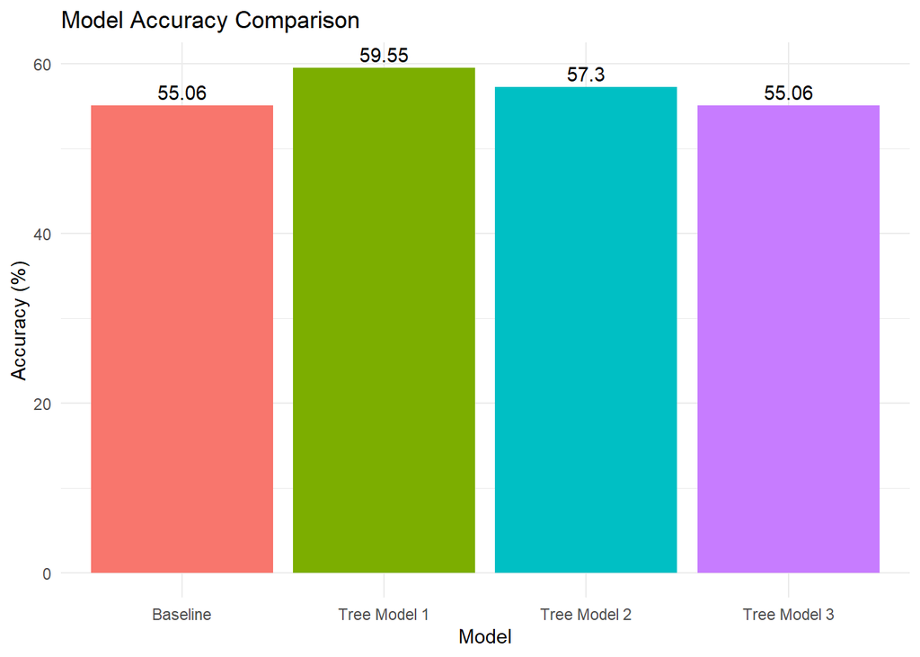

```r
# Display comparison
# YOUR CODE HERE

result = data.frame(
  Model = c("Baseline", "Tree Model 1", "Tree Model 2", "Tree Model 3"),
  Accuracy = c(
    round(acc_val * 100,2),
    round(acc_val1 * 100, 2),
    round(acc_val2 * 100, 2),
    round(acc_val3 * 100, 2)
  )
)

ggplot(result, aes(x = Model, y = Accuracy, fill = Model)) +
  geom_bar(stat = "identity") +
  geom_text(aes(label = Accuracy), vjust = -0.4) +
  labs(title = "Model Accuracy Comparison",
       x = "Model",
       y = "Accuracy (%)") +
  theme_minimal() +
  theme(legend.position = "none")
```

**Question 4.2:** Which tree has the best test accuracy? Is it the most complex tree? What does this tell you about overfitting?

**Your Answer:** The first comparison with cp of 0.18 performed best with accuracy of 59.55%, a small improvement from the baseline model of 55.06 percent. Decreasing cp values would increase the risk of overfitting.

# Section 5: Pruning and Cross-Validation (4 minutes)

## 5.1 Find Optimal CP Using Cross-Validation

Use cross-validation to find the optimal complexity parameter.

```r
# Build a full tree
# YOUR CODE HERE

set.seed(12)

train_control <- trainControl(method = "repeatedcv", number = 10, repeats = 2) # 10 partitions, and repeat twice

gridTune <- expand.grid(cp = seq(0.001, 0.05, by = 0.01)) # parameters of the model

cross_ValTree <- train(Churn ~ .,
                        data = trainData,
                        method = "rpart",
                        trControl = train_control,
                        tuneGrid = gridTune,
                        maxdepth = 5,
                        minbucket = 5)



# Display the cp table
# YOUR CODE HERE
print(cross_ValTree$results)
```

```
##      cp  Accuracy     Kappa AccuracySD   KappaSD
## 1 0.001 0.6344156 0.2237205 0.08476364 0.1902460
## 2 0.011 0.6391775 0.2191561 0.07466451 0.1710102
## 3 0.021 0.6608442 0.2376740 0.05758706 0.1582657
## 4 0.031 0.6516558 0.2124149 0.06542763 0.1685178
## 5 0.041 0.6585823 0.2290235 0.05765204 0.1424931
```

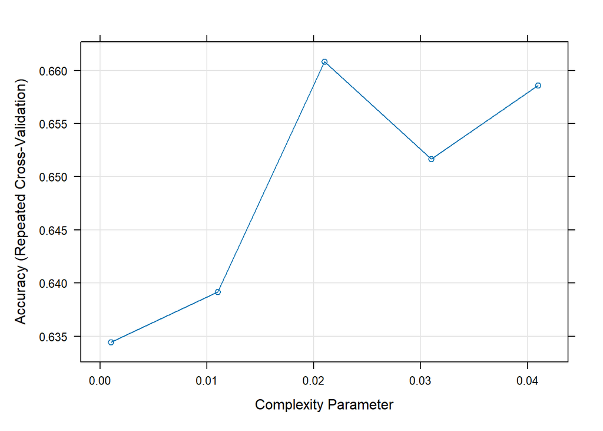

```r
# Plot cross-validation results
# YOUR CODE HERE
plot(cross_ValTree)
```

```r
# Find the best cp value
# YOUR CODE HERE
best_cp_CV = cross_ValTree$bestTune
cat("Best CP value based on cross-validation:", best_cp_CV$cp, "\n")
```

```
## Best CP value based on cross-validation: 0.021
```

**Question 5.1:** What is the optimal `cp` value according to cross-validation? What is the cross-validation error at this point?

**Your Answer:** Optimal cp was 0.02 based on higher accuracy of 66.08%. This corresponds to a cross validation error of approximately 0.339 i.e., 34%

## 5.2 Prune the Tree

Prune the tree using the optimal cp value.

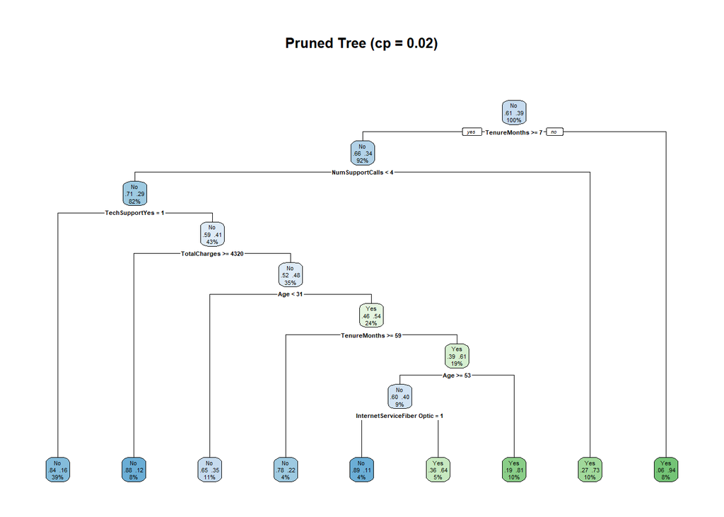

```r
# Prune the tree using optimal cp
# YOUR CODE HERE

best_cp =  best_cp_CV$cp

#prune_tree =  prune(tree_full, cp = best_cp)

pruned_tree <- cross_ValTree$finalModel


# Visualize the pruned tree
# YOUR CODE HERE
rpart.plot(pruned_tree, type = 2, extra = 104, fallen.leaves = TRUE,
           main = sprintf("Pruned Tree (cp = %.2f)", best_cp))
```

```r
# Evaluate pruned tree on test set
# YOUR CODE HERE
#pruned_pred_class <- predict(pruned_tree, newdata = X_test, type = "class")
pruned_pred_class <- predict(cross_ValTree, newdata = X_test)


pruned_df <- data.frame(
  Actual_Values = y_test,
  Predicted_Values = pruned_pred_class
)

# Converting Yes/No to 1/0
pruned_df$Actual_Values <- ifelse(pruned_df$Actual_Values == "Yes", 1, 0)
pruned_df$Predicted_Values <- ifelse(pruned_df$Predicted_Values == "Yes", 1, 0)

prune_acc <- accuracy(pruned_df$Actual_Values, pruned_df$Predicted_Values)
cat(sprintf("Test Accuracy (cp = %.2f): %.2f%%\n", best_cp, prune_acc*100))
```

```
## Test Accuracy (cp = 0.02): 60.67%
```

**Question 5.2:** Did pruning improve or hurt the test set performance compared to your original tree? By how much?

**Your Answer:** It improved the model, so it did not hurt the test set performance, it had an accuracy of 60.67% compared to the baseline model of 55.06%. It increased by 5.61%

# Section 6: Reflection and Conclusions (Optional - if time permits)

**Question 6.1:** Based on your analysis, which customers are most at risk of churning? What business recommendations would you make to reduce churn?

**Question 6.2:** What are the limitations of using decision trees for this problem? How might you address these limitations?

**Your Answer:** One drawback of using a decision tree for this classification problem is that it can easily overfit, especially given the small number of observations in this study. The model’s results indicate that more data or better tuning of its settings could improve its predictive performance. To overcome these issues, it might help to compare them with other models that handle categorical variables, such as Random Forests, which combine many trees to reduce overfitting and improve generalization.

# Submission

Save this file with your answers and code filled in. Make sure all code chunks run without errors before submitting.

**Checklist before submission:** - [x] All code chunks execute successfully - [x] All questions are answered - [x] Visualizations are clearly labeled and readable - [x] Your name is at the top of the document